# Final Paper Results

Caylee Collins and Kate Miller

This file runs our three analysis scripts and puts the results we used in the final paper in one place. The scripts still do all of their calculations without rendering three extra HTML reports, but this report shows the six tables and six figures from the paper, beginning with Figure 1 (the four-panel adjusted-regression residual and normal Q-Q diagnostics in the Assumptions subsection). The other five figures are numbered 2–6.

# Assumptions and Regression Diagnostics

Figure 1 combines four panels for the adjusted PHQ-9 and GAD-7 regression models. The top panels display residuals against fitted scores, which can reveal curvature or changing error variance. The bottom panels contain normal Q-Q plots, which show departures from the normality assumption for regression errors. The orange lines indicate smoothed residual patterns (top) or reference lines (bottom). Each outcome uses up to 5,000 reproducibly selected observations for the visualization; both models were fitted using all complete observations. These plots do not establish independent errors or absence of multicollinearity.

FIGURE 1. Residuals versus fitted values and normal Q-Q plots for adjusted PHQ-9 and GAD-7 regression models

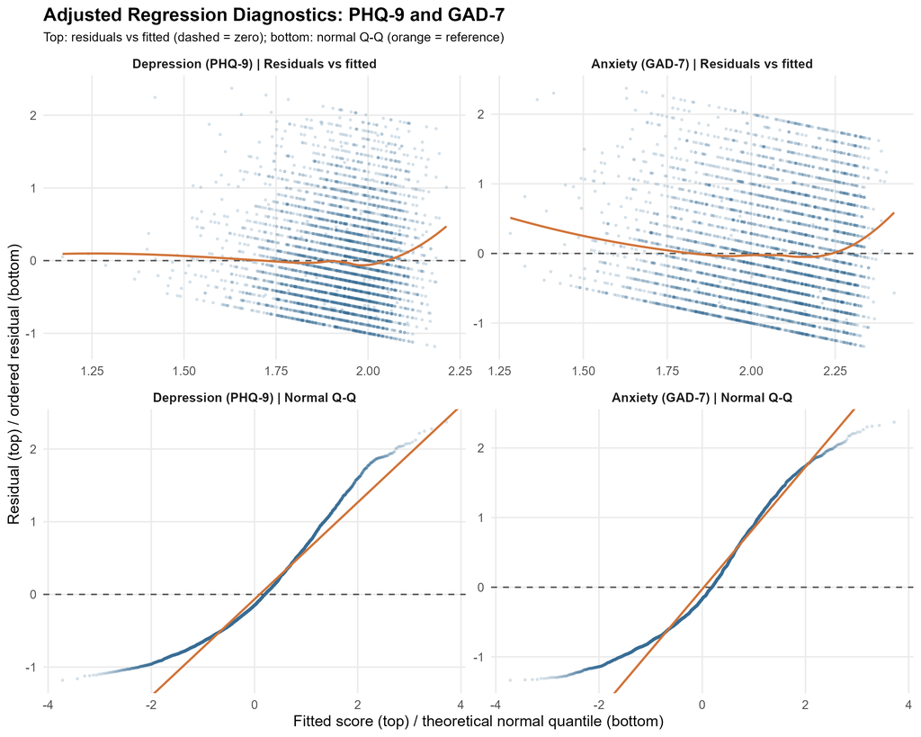

# Descriptive Results

TABLE I. Statistics for Depression (PHQ) and Anxiety (GAD) by Survey Period

| Period | Outcome | N | Mean | SD | SE | 95% CI |
| --- | --- | --- | --- | --- | --- | --- |
| 2017-2018 | GAD | 51065 | 1.984 | 0.788 | 0.003 | (1.977, 1.990) |
| 2017-2018 | PHQ | 51639 | 1.892 | 0.670 | 0.003 | (1.886, 1.898) |
| 2022-2023 | GAD | 41047 | 2.155 | 0.831 | 0.004 | (2.147, 2.163) |
| 2022-2023 | PHQ | 41469 | 1.990 | 0.703 | 0.003 | (1.984, 1.997) |

FIGURE 2. Average depression and anxiety scores across survey periods

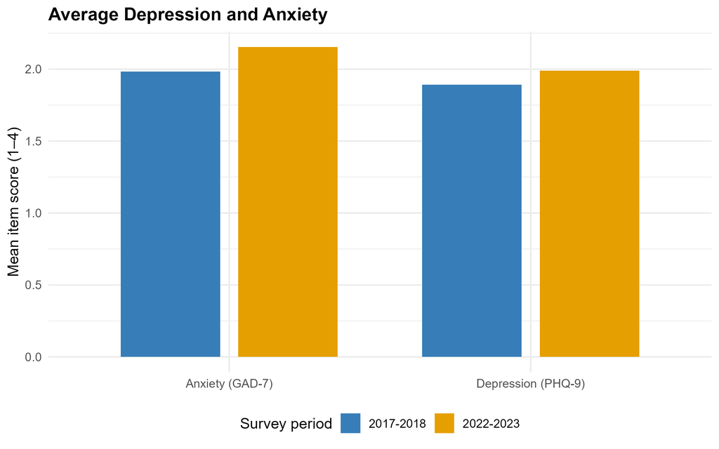

# Regression and Interaction Results

TABLE II. Regression Results for Depression (PHQ) and Anxiety (GAD)

| Outcome | Predictor | Coefficient | SE | 95% CI | t | p |
| --- | --- | --- | --- | --- | --- | --- |
| PHQ | Intercept | 1.913 | 0.014 | (1.886, 1.941) | 136.85 | <0.001 |
| PHQ | Period: 2022–2023 | 0.079 | 0.005 | (0.069, 0.090) | 14.90 | <0.001 |
| PHQ | Gender: Women | 0.147 | 0.006 | (0.136, 0.158) | 26.30 | <0.001 |
| PHQ | Field: STEM | -0.038 | 0.005 | (-0.048, -0.028) | -7.39 | <0.001 |
| PHQ | Race: Asian | 0.019 | 0.007 | (0.005, 0.033) | 2.63 | 0.009 |
| PHQ | Race: Black | 0.058 | 0.009 | (0.039, 0.076) | 6.18 | <0.001 |
| PHQ | Race: Hispanic | 0.082 | 0.009 | (0.064, 0.100) | 8.91 | <0.001 |
| PHQ | Race: Middle Eastern | 0.125 | 0.020 | (0.085, 0.165) | 6.17 | <0.001 |
| PHQ | Year: Second year | 0.062 | 0.007 | (0.049, 0.076) | 9.14 | <0.001 |
| PHQ | Year: Third year | 0.082 | 0.007 | (0.068, 0.096) | 11.54 | <0.001 |
| PHQ | Year: Fourth year + | 0.071 | 0.007 | (0.057, 0.085) | 9.65 | <0.001 |
| PHQ | Financial status | 0.024 | 0.002 | (0.019, 0.028) | 10.33 | <0.001 |
| PHQ | Age | -0.011 | 0.000 | (-0.012, -0.011) | -24.58 | <0.001 |
| GAD | Intercept | 1.939 | 0.017 | (1.907, 1.972) | 117.29 | <0.001 |
| GAD | Period: 2022–2023 | 0.144 | 0.006 | (0.132, 0.156) | 22.85 | <0.001 |
| GAD | Gender: Women | 0.297 | 0.007 | (0.284, 0.310) | 44.95 | <0.001 |
| GAD | Field: STEM | -0.038 | 0.006 | (-0.050, -0.026) | -6.23 | <0.001 |
| GAD | Race: Asian | -0.098 | 0.009 | (-0.115, -0.081) | -11.37 | <0.001 |
| GAD | Race: Black | -0.062 | 0.011 | (-0.084, -0.041) | -5.64 | <0.001 |
| GAD | Race: Hispanic | 0.015 | 0.011 | (-0.007, 0.036) | 1.35 | 0.176 |
| GAD | Race: Middle Eastern | 0.101 | 0.024 | (0.054, 0.148) | 4.21 | <0.001 |
| GAD | Year: Second year | 0.097 | 0.008 | (0.081, 0.113) | 11.98 | <0.001 |
| GAD | Year: Third year | 0.110 | 0.008 | (0.094, 0.127) | 13.03 | <0.001 |
| GAD | Year: Fourth year + | 0.110 | 0.009 | (0.093, 0.127) | 12.68 | <0.001 |
| GAD | Financial status | 0.020 | 0.003 | (0.015, 0.026) | 7.57 | <0.001 |
| GAD | Age | -0.012 | 0.001 | (-0.013, -0.011) | -22.09 | <0.001 |

TABLE III. Interactions Between Survey Period and Gender and STEM Status

| Outcome | Interaction | Coefficient | SE | 95% CI | t | p |
| --- | --- | --- | --- | --- | --- | --- |
| PHQ | Period × Gender | 0.039 | 0.010 | (0.020, 0.059) | 3.97 | <0.001 |
| PHQ | Period × STEM | 0.122 | 0.010 | (0.103, 0.141) | 12.64 | <0.001 |
| GAD | Period × Gender | 0.079 | 0.012 | (0.056, 0.101) | 6.73 | <0.001 |
| GAD | Period × STEM | 0.131 | 0.011 | (0.108, 0.153) | 11.43 | <0.001 |

FIGURE 3. Depression and anxiety scores by gender, STEM status, and survey period

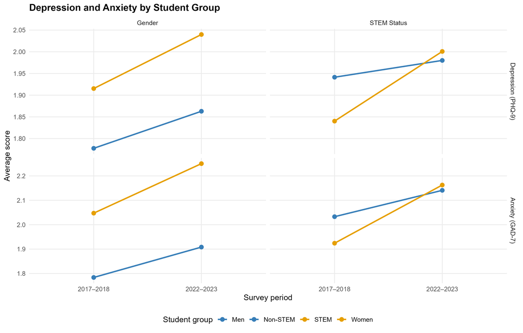

# Predictive Model Results

TABLE IV. Predictive Model Comparison on the Testing Set

| Outcome | Model | RMSE | MAE | R² | Accuracy (%) |
| --- | --- | --- | --- | --- | --- |
| Depression | Gender × STEM Regression | 0.4630 | 0.3539 | 0.5693 | 80.68 |
| Depression | Linear Regression | 0.4630 | 0.3539 | 0.5692 | 80.68 |
| Depression | LASSO Regression | 0.4630 | 0.3539 | 0.5692 | 80.68 |
| Depression | Ridge Regression | 0.4649 | 0.3581 | 0.5690 | 80.79 |
| Depression | Random Forest | 0.4674 | 0.3620 | 0.5641 | 80.42 |
| Depression | XGBoost | 0.4709 | 0.3588 | 0.5546 | 80.15 |
| Depression | Regression Tree | 0.4884 | 0.3778 | 0.5206 | 78.31 |
| Depression | Baseline | 0.7051 | 0.5727 | 0.0000 | 65.40 |
| Anxiety | LASSO Regression | 0.5426 | 0.4187 | 0.5682 | 80.76 |
| Anxiety | Gender × STEM Regression | 0.5427 | 0.4187 | 0.5681 | 80.76 |
| Anxiety | Linear Regression | 0.5427 | 0.4187 | 0.5681 | 80.79 |
| Anxiety | Ridge Regression | 0.5438 | 0.4245 | 0.5677 | 80.83 |
| Anxiety | Random Forest | 0.5462 | 0.4282 | 0.5642 | 80.55 |
| Anxiety | XGBoost | 0.5518 | 0.4245 | 0.5545 | 80.55 |
| Anxiety | Regression Tree | 0.5695 | 0.4453 | 0.5243 | 79.58 |
| Anxiety | Baseline | 0.8254 | 0.6900 | 0.0000 | 64.53 |

TABLE V. Model Performance With and Without the Other Mental Health Score

| Outcome | Model | RMSE | MAE | R² | Accuracy (%) |
| --- | --- | --- | --- | --- | --- |
| Depression | With anxiety | 0.4630 | 0.3539 | 0.5692 | 80.68 |
| Depression | Student characteristics | 0.6568 | 0.5250 | 0.1324 | 68.35 |
| Anxiety | With depression | 0.5427 | 0.4187 | 0.5681 | 80.79 |
| Anxiety | Student characteristics | 0.7698 | 0.6331 | 0.1302 | 68.03 |

TABLE VI. Model Performance on the Validation Set

| Outcome | Model | RMSE | MAE | R² | Accuracy (%) |
| --- | --- | --- | --- | --- | --- |
| Depression | Gender × STEM Regression | 0.4591 | 0.3525 | 0.5746 | 79.51 |
| Depression | Linear Regression | 0.4591 | 0.3527 | 0.5745 | 79.39 |
| Depression | LASSO Regression | 0.4592 | 0.3528 | 0.5744 | 79.54 |
| Depression | XGBoost | 0.4732 | 0.3606 | 0.5484 | 79.51 |
| Anxiety | Gender × STEM Regression | 0.5330 | 0.4092 | 0.5762 | 79.87 |
| Anxiety | LASSO Regression | 0.5331 | 0.4093 | 0.5761 | 79.93 |
| Anxiety | Linear Regression | 0.5331 | 0.4092 | 0.5760 | 79.90 |
| Anxiety | XGBoost | 0.5456 | 0.4169 | 0.5574 | 79.57 |

FIGURE 4. Observed versus predicted depression and anxiety scores on the validation set

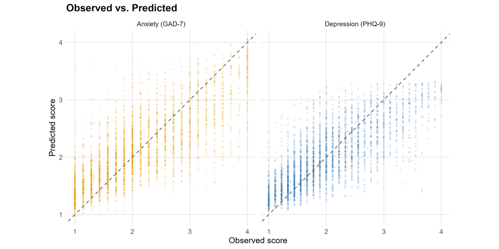

FIGURE 5. Residual plots for the selected predictive models

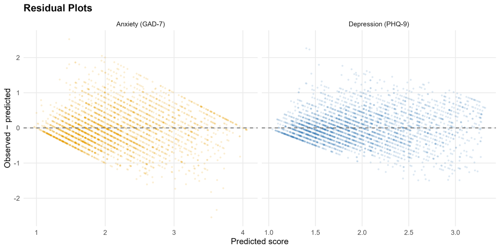

FIGURE 6. Confusion matrices for depression and anxiety classification on the validation set

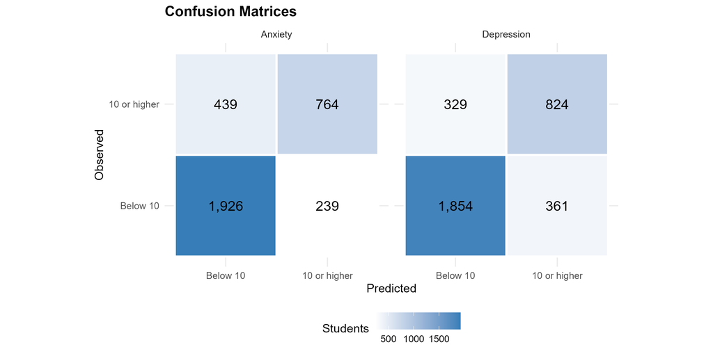

*The original scripts also calculate other results, but this report shows only the tables and figures used in the paper.*